# MATH 2310 Lab 2

#### Exponential Distributions

Similarly to the discrete distributions, we have the similar logic for the exponential except now ‘d’ is the continuous density function and can be plotted over an interval.

Here we use the `curve()` function to plot the exponential pdf for several different lambdas (denoted ‘rate’ in the code.)

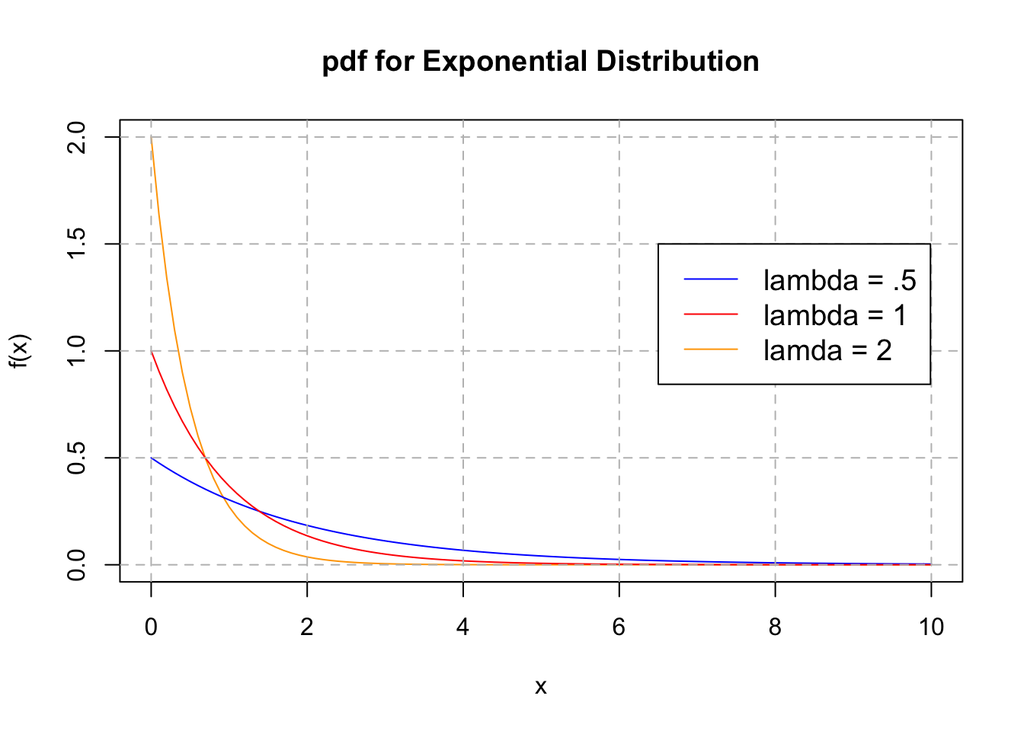

```r
#plot PDF curves
#Plots first curve for lambda =2
curve(dexp(x, rate = 2), from=0, to=10, col='orange',ylab='f(x)', main ='pdf for Exponential Distribution')

#adds more curves for additional lambdas (add = TRUE ads to the plot instead of starting a new one)
curve(dexp(x, rate = .5), from=0, to=10, col='blue', add= TRUE)
curve(dexp(x, rate = 1), from=0, to=10, col='red', add=TRUE)

#Adds a grid for reference
grid(nx = NULL, ny = NULL, lty = 2, col = "gray", lwd = 1)

#add legend
legend(6.5, 1.5, legend=c("lambda = .5", "lambda = 1", "lamda = 2"),
       col=c("blue", "red", "orange"), lty=1, cex=1.2)
```

Note how the shape changes as lamda increases/decreases.

Similarly you could plot the CDF.

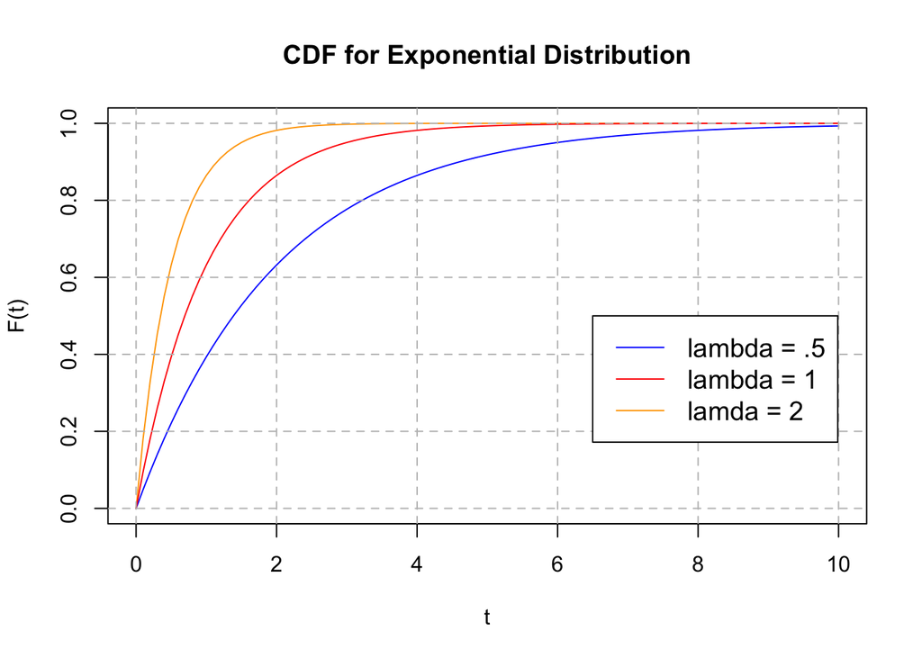

```r
#plot PDF curves
#Plots first curve for lambda =2
curve(pexp(x, rate = 2), from=0, to=10, col='orange',ylab='F(t)', xlab ='t', main ='CDF for Exponential Distribution')

#adds more curves for additional lambdas (add = TRUE ads to the plot instead of starting a new one)
curve(pexp(x, rate = .5), from=0, to=10, col='blue', add= TRUE)
curve(pexp(x, rate = 1), from=0, to=10, col='red', add=TRUE)

#Adds a grid for reference
grid(nx = NULL, ny = NULL, lty = 2, col = "gray", lwd = 1)

#add legend
legend(6.5, .5, legend=c("lambda = .5", "lambda = 1", "lamda = 2"),
       col=c("blue", "red", "orange"), lty=1, cex=1.2)
```

Looking at the graph of the CDF how would you identify the 50th percentile?

How is the graph of the CDF related to the pdf?

Why does the CDF approach 1 as t increases?

You can also create a histogram of sample data and then overlay a distribution - it should match pretty close if you sample enough.

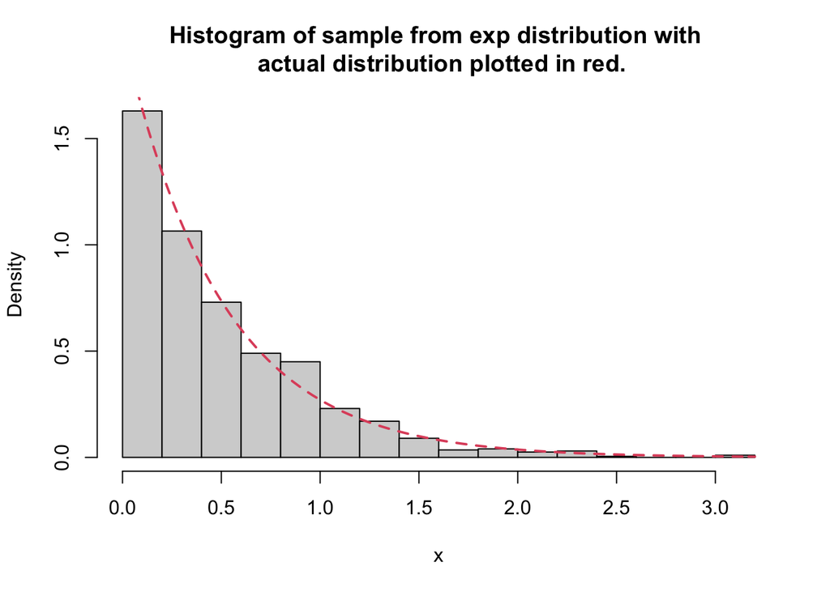

```r
#Sample 1000 times for lambda =2
z <- rexp(1000,rate = 2)
# Make a histogram!
hist(z, prob = TRUE, breaks=20, main='Histogram of sample from exp distribution with \n actual distribution plotted in red.', xlab='x')
#Overlay the actual distribution
curve(dexp(x, rate = 2), col = 2, lty = 2, lwd = 2, add = TRUE)
```

These should be pretty close because the sample data is *generated from* the distribution plotted. In general this will not be the case. You would create a histogram from data from an unknown distribution, decide what *type* of distribution makes sense, and then *choose/fit* the parameters to match it as close as possible. There are also algorithms to choose the best parameter as well.

You can also use the `pexp` function to calculate probabilities of ranges, this is equivalent to integrals of `dexp`. Since this is continuous we can be pretty lax about $<$ vs $\leq$ etc.

Suppose we have an exponential distribution with $\lambda =2$ and we want the probability that the variable is between 0.5 and 3. We know from class that this can be evaluated by:

$$P(0.5<X<3) =
P(X<3)-P(X<.5)=F(3)-F(.5)=\int_.5^32e^{-2x}dx=-e^{-6}-\left(-e^{-1}\right)$$

Method 1 Integrate `dexp`:

```r
#Take the integral of dexp from 0.5 to 3

# Fist define the function and store it as the object f
f<-function(x) dexp(x,rate=2)

#then integrate the function (you can use Inf in the range!)
integrate(f, 0.5, 3)
```

```
## 0.3654007 with absolute error < 4.1e-15
```

Method 2 Use `pexp` (remember pexp is the built in function for the cdf or F):

```r
#Take the integral of dexp from 0.5 to 3
pexp(3, 2)-pexp(0.5,2)
```

```
## [1] 0.3654007
```

Method 3 Use the known values:

```r
#The exponential e^x is denoted exp(x)
-exp(-6)-(-exp(-1))
```

```
## [1] 0.3654007
```

These all produce the same answer as expected. The method using pexp() is the easiest though (just like we used F(x) in class when we had a formula for it).